# Data Analysis for Solar-Powered AI Healthcare Units

Research Team

May 12, 2025

## Introduction

This report analyzes a synthetic dataset designed to train four TinyLLaMA models for generating Subjective, Objective, Assessment, and Plan (SOAP) notes in a solar-powered, on-premises AI unit for rural healthcare. The dataset, comprising 1,032 patient records with demographics, chief complaints, transcriptions, and SOAP notes, simulates clinical encounters to enable offline medical transcription and diagnostic support. An augmented dataset provides paraphrased SOAP sections to enhance model robustness. The analysis aims to explore the dataset’s structure, preprocess it for fine-tuning, evaluate potential biases, and document the process transparently to invite public critique. This work supports the development of affordable, sustainable AI solutions for remote regions with limited infrastructure.

```r
# Load required libraries
library(jsonlite)
library(dplyr)
library(ggplot2)
library(tidyr)

# Verify dataset availability
patients_file <- "../data/synthetic_patients_with_soap.jsonl"
augmented_file <- "../data/soap_augmented.jsonl"
if (!file.exists(patients_file) || !file.exists(augmented_file)) {
  stop("Dataset files not found in data directory")
}

# Load datasets (limited to first 10 rows for quick verification)
patients <- stream_in(file(patients_file), verbose = FALSE)[1:10, ]
augmented <- stream_in(file(augmented_file), verbose = FALSE)[1:10, ]

# Display row counts
cat("Primary dataset rows (sample):", nrow(patients), "\n")
```

```
## Primary dataset rows (sample): 10
```

```r
cat("Augmented dataset rows (sample):", nrow(augmented), "\n")
```

```
## Augmented dataset rows (sample): 10
```

## Data Description

This section provides an overview of the synthetic datasets structure, including patient demographics, chief complaints, transcriptions, and SOAP notes, as well as the augmented datasets paraphrased SOAP sections.

```r
# Display structure of primary dataset
str(patients, max.level = 1)
```

```
## 'data.frame':    10 obs. of  11 variables:
##  $ row_id         : chr  "row0000" "row0001" "row0002" "row0003" ...
##  $ gender         : chr  "Male" "Female" "Female" "Non" ...
##  $ age            : int  34 23 31 37 77 27 78 59 61 31
##  $ smoker         : chr  "Yes" "No" "Yes" "Yes" ...
##  $ drinker        : chr  "No" "No" "Yes" "No" ...
##  $ blood_pressure : chr  "126/84" "110/86" "159/68" "130/68" ...
##  $ chief_complaint: chr  "Weight loss" "Pediatric checkup" "Sinus infection" "Cold symptoms" ...
##  $ subjective     : chr  "The patient, a 34-year-old male, is concerned about unexplained weight loss. He reports losing approximately 15"| __truncated__ "The patient is a 23-year-old female here for her son's pediatric checkup. She reports that her son, who is five"| __truncated__ "The patient i…
##  $ objective      : chr  "The patient's blood pressure is 126/84, which is within the normal range. A physical exam revealed normal respi"| __truncated__ "The patient is a non-smoker and non-drinker with a blood pressure of 110/86. Her son weighs 16 pounds and is 26"| __truncated__ "The patient's…
##  $ assessment     : chr  "The patient is experiencing unexplained weight loss over the past three months. Potential causes could include "| __truncated__ "The son's overall health is good. Growth and development are on track. The rash on the cheeks is likely mild ec"| __truncated__ "The presentat…
##  $ plan           : chr  "Order blood tests to evaluate thyroid function and screen for conditions such as diabetes. Advise the patient t"| __truncated__ "Continue current breastfeeding and sleep routines. Manage skincare with mild soap and moisturizer, possibly inc"| __truncated__ "Start an anti…
```

```r
# Display structure of augmented dataset
str(augmented, max.level = 1)
```

```
## 'data.frame':    10 obs. of  4 variables:
##  $ id       : chr  "batch_req_681f9a20d2f081909eb819a21dd49406" "batch_req_681f9a20e614819085ff9ed8d3cfdd6a" "batch_req_681f9a210308819095dc5c4de182f89a" "batch_req_681f9a2121bc81909a2ea146a481a2fa" ...
##  $ custom_id: chr  "row0000_subjective_simple" "row0000_subjective_bullets" "row0000_subjective_narrative" "row0000_subjective_brev_bp" ...
##  $ response :'data.frame':   10 obs. of  3 variables:
##  $ error    : logi  NA NA NA NA NA NA ...
```

### Demographic Distribution

We examine the distribution of demographic variables to understand the dataset’s representativeness.

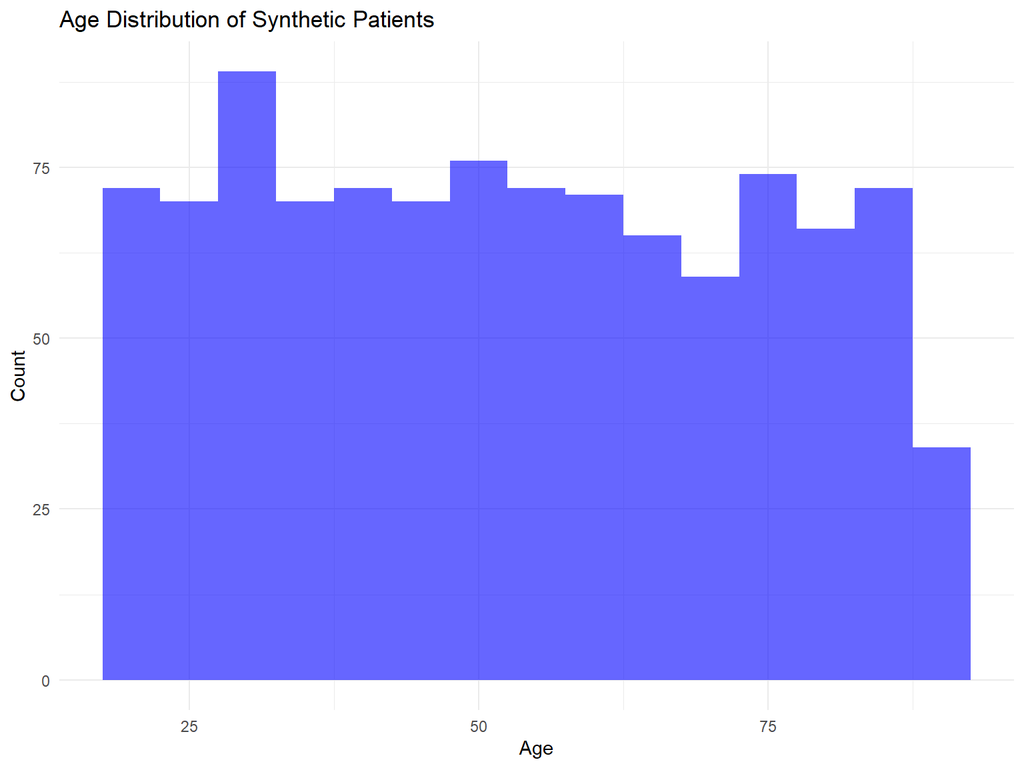

```r
# Load the full primary dataset for analysis
patients_full <- stream_in(file("../data/synthetic_patients_with_soap.jsonl"), verbose = FALSE)

# Create a histogram of age distribution
ggplot(patients_full, aes(x = age)) +
  geom_histogram(binwidth = 5, fill = "blue", alpha = 0.6) +
  labs(title = "Age Distribution of Synthetic Patients", x = "Age", y = "Count") +
  theme_minimal()
```

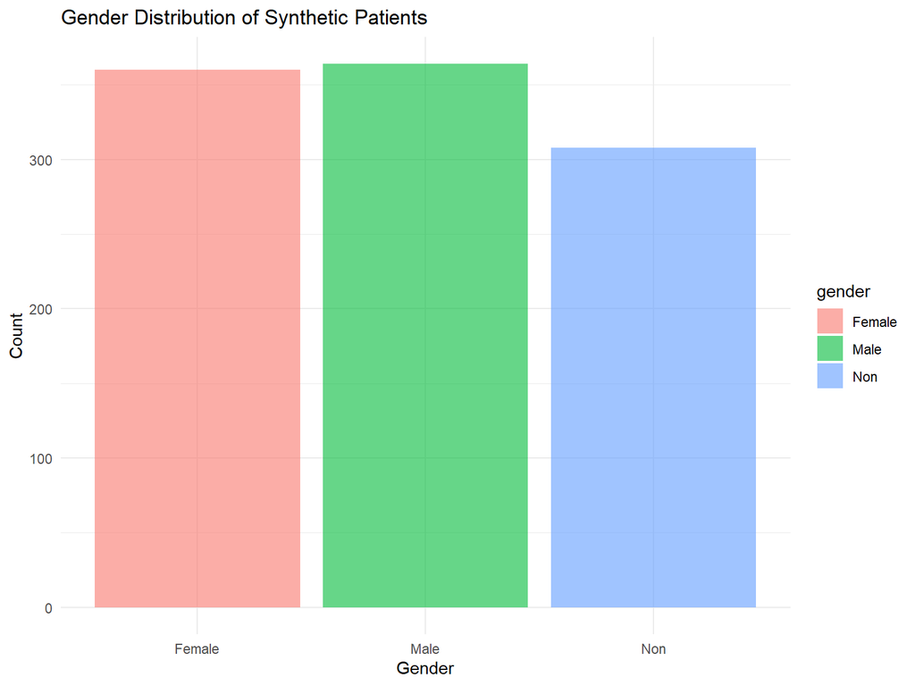

```r
# Create a bar plot of gender distribution
ggplot(patients_full, aes(x = gender, fill = gender)) +
  geom_bar(alpha = 0.6) +
  labs(title = "Gender Distribution of Synthetic Patients", x = "Gender", y = "Count") +
  theme_minimal()
```

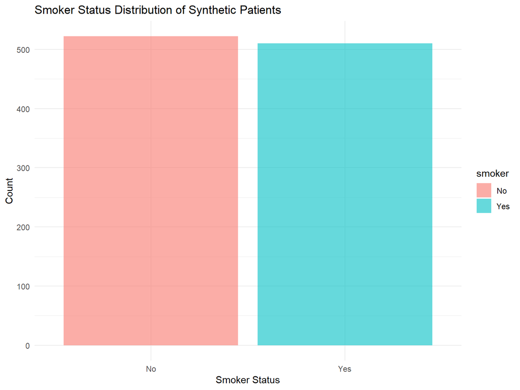

```r
# Create a bar plot of smoker status distribution
ggplot(patients_full, aes(x = smoker, fill = smoker)) +
  geom_bar(alpha = 0.6) +
  labs(title = "Smoker Status Distribution of Synthetic Patients", x = "Smoker Status", y = "Count") +
  theme_minimal()
```

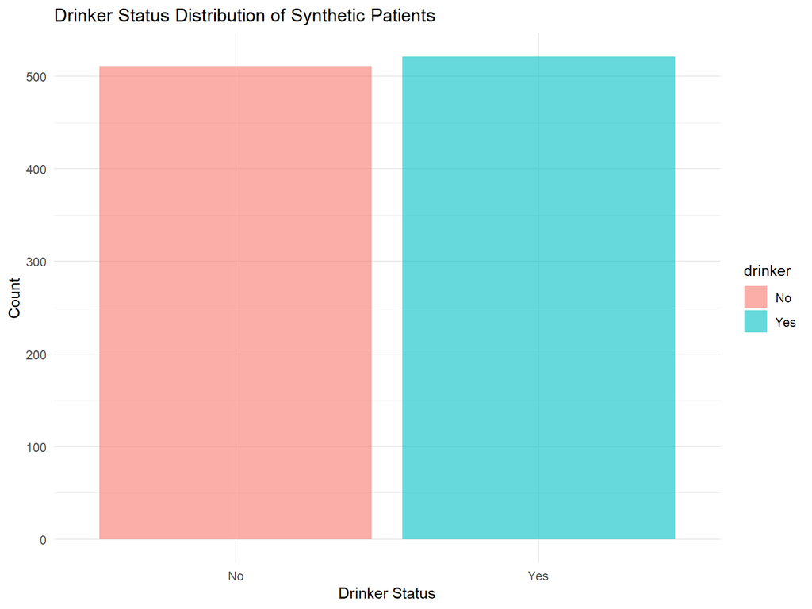

```r
# Create a bar plot of drinker status distribution
ggplot(patients_full, aes(x = drinker, fill = drinker)) +
  geom_bar(alpha = 0.6) +
  labs(title = "Drinker Status Distribution of Synthetic Patients", x = "Drinker Status", y = "Count") +
  theme_minimal()
```

### Chief Complaints

This subsection examines the frequency of chief complaints to identify common health concerns in the synthetic dataset.

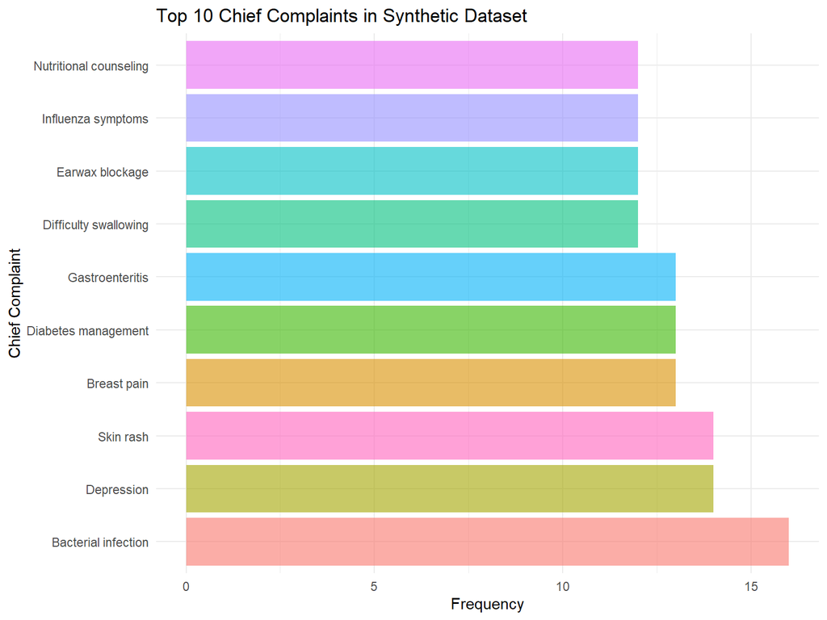

```r
# Calculate the top 10 chief complaints
top_complaints <- patients_full %>%
  count(chief_complaint, sort = TRUE) %>%
  slice_head(n = 10)

# Create a bar plot of the top 10 chief complaints without a legend
ggplot(top_complaints, aes(x = reorder(chief_complaint, -n), y = n, fill = chief_complaint)) +
  geom_bar(stat = "identity", alpha = 0.6) +
  labs(title = "Top 10 Chief Complaints in Synthetic Dataset", x = "Chief Complaint", y = "Frequency") +
  theme_minimal() +
  coord_flip() +
  theme(legend.position = "none")
```

### SOAP Notes Summary

This subsection summarizes the structure of the SOAP notes, including the distribution of sections and formats in the augmented dataset.

```r
# Load the full augmented dataset
augmented_full <- stream_in(file("../data/soap_augmented.jsonl"), verbose = FALSE)

# Extract section and format from custom_id
augmented_full <- augmented_full %>%
  mutate(
    section = sub("^row[0-9]+_([^_]+)_.*$", "\\1", custom_id),
    format = sub("^row[0-9]+_[^_]+_(.*)$", "\\1", custom_id),
    # Extract the paraphrased text from the nested response column
    text = sapply(response$body$choices, function(x) x$message$content)
  )

# Sample paraphrased sections for the first patient (row0000) for Subjective section
sample_soap <- augmented_full %>%
  filter(grepl("^row0000", custom_id) & section == "subjective") %>%
  select(format, text)

# Display the sample
print(sample_soap)
```

````
##      format
## 1    simple
## 2   bullets
## 3 narrative
## 4   brev_bp
## 5  detailed
##                                                                                                                                                                                                                                                                                                          …
## 1                             [\n    "A 34-year-old man is worried about losing weight without an apparent reason. He mentions a weight loss of around 15 pounds in the last three months, even though his diet has remained the same. He does not experience significant digestive problems but does fee…
## 2                                                                                                                                                                                                                                                                                                        …
## 3                                                                                                ```json\n[\n  "A 34-year-old male patient is worried due to losing around 15 pounds in the last three months, despite no alterations to his dietary habits. He mentions not experiencing any significant…
## 4                                                                                                                                                                                                                                                                                                       `…
## 5 ```json\n[\n    "A 34-year-old male presents with concerns regarding unintended weight loss. Over the past three months, he has observed a reduction of around 15 pounds without any alterations in his dietary habits. He denies experiencing significant digestive problems, though he occasionally f…
````

## Data Preprocessing

To train four TinyLLaMA models, we preprocess the augmented dataset by splitting it into four subsets, each corresponding to a SOAP section: Subjective, Objective, Assessment, and Plan. This ensures each model is fine-tuned on relevant data.

```r
# Ensure the data directory exists
dir.create("../data", showWarnings = FALSE)

# Split the augmented dataset into four subsets
subjective <- augmented_full %>% filter(section == "subjective") %>% select(format, text)
objective <- augmented_full %>% filter(section == "objective") %>% select(format, text)
assessment <- augmented_full %>% filter(section == "assessment") %>% select(format, text)
plan <- augmented_full %>% filter(section == "plan") %>% select(format, text)

# Save each subset as a JSONL file
write_json(subjective, "../data/subjective.jsonl", auto_unbox = TRUE, pretty = TRUE)
write_json(objective, "../data/objective.jsonl", auto_unbox = TRUE, pretty = TRUE)
write_json(assessment, "../data/assessment.jsonl", auto_unbox = TRUE, pretty = TRUE)
write_json(plan, "../data/plan.jsonl", auto_unbox = TRUE, pretty = TRUE)

# Confirm the files were created
cat("Preprocessed files saved:\n")
```

```
## Preprocessed files saved:
```

```r
cat("Subjective:", file.exists("../data/subjective.jsonl"), "\n")
```

```
## Subjective: TRUE
```

```r
cat("Objective:", file.exists("../data/objective.jsonl"), "\n")
```

```
## Objective: TRUE
```

```r
cat("Assessment:", file.exists("../data/assessment.jsonl"), "\n")
```

```
## Assessment: TRUE
```

```r
cat("Plan:", file.exists("../data/plan.jsonl"), "\n")
```

```
## Plan: TRUE
```

## Bias and Uncertainties Analysis

This section examines potential biases in the synthetic dataset, such as demographic imbalances, and discusses uncertainties that may affect model performance in real-world settings.

### Demographic Bias

The synthetic dataset uses random assignments for demographic variables like gender, age, smoker, and drinker status. Imbalances in these distributions may bias model predictions, potentially affecting fairness in healthcare applications.

```r
# Calculate proportions for gender, smoker, and drinker
gender_prop <- prop.table(table(patients_full$gender)) * 100
smoker_prop <- prop.table(table(patients_full$smoker)) * 100
drinker_prop <- prop.table(table(patients_full$drinker)) * 100

# Display the proportions
cat("Gender Proportions (%):\n")
```

```
## Gender Proportions (%):
```

```r
print(gender_prop)
```

```
##
##   Female     Male      Non
## 34.88372 35.27132 29.84496
```

```r
cat("\nSmoker Proportions (%):\n")
```

```
##
## Smoker Proportions (%):
```

```r
print(smoker_prop)
```

```
##
##      No     Yes
## 50.5814 49.4186
```

```r
cat("\nDrinker Proportions (%):\n")
```

```
##
## Drinker Proportions (%):
```

```r
print(drinker_prop)
```

```
##
##      No     Yes
## 49.5155 50.4845
```

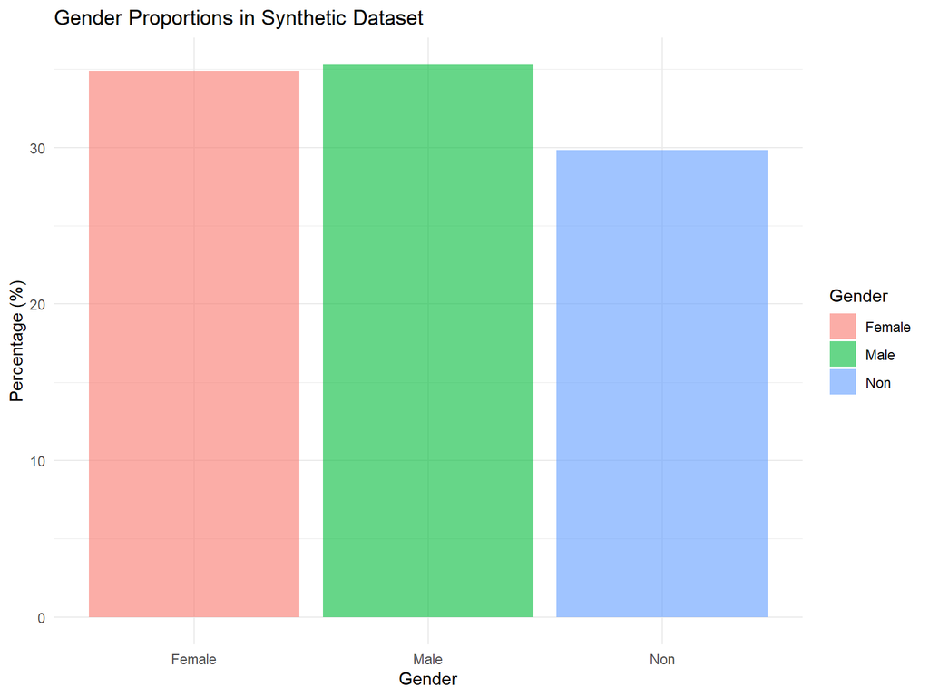

```r
# Convert gender proportions to a data frame for plotting
gender_df <- as.data.frame(prop.table(table(patients_full$gender)) * 100)
colnames(gender_df) <- c("Gender", "Percentage")

# Create a bar plot of gender proportions
ggplot(gender_df, aes(x = Gender, y = Percentage, fill = Gender)) +
  geom_bar(stat = "identity", alpha = 0.6) +
  labs(title = "Gender Proportions in Synthetic Dataset", x = "Gender", y = "Percentage (%)") +
  theme_minimal()
```

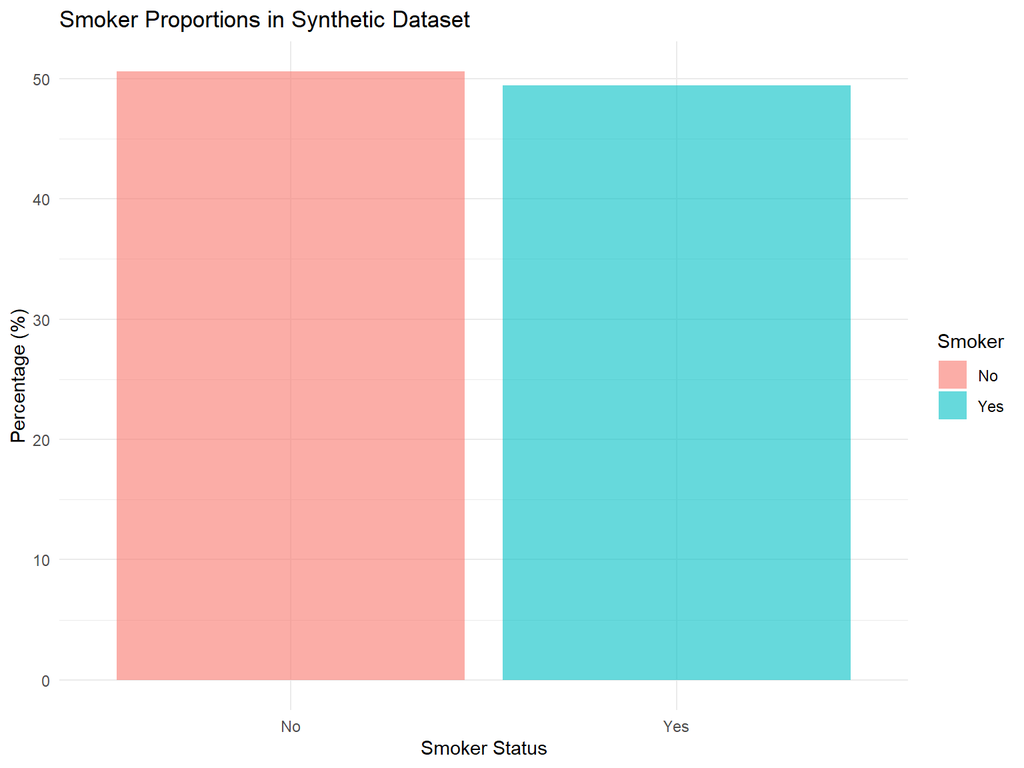

```r
# Convert smoker proportions to a data frame for plotting
smoker_df <- as.data.frame(prop.table(table(patients_full$smoker)) * 100)
colnames(smoker_df) <- c("Smoker", "Percentage")

# Create a bar plot of smoker proportions
ggplot(smoker_df, aes(x = Smoker, y = Percentage, fill = Smoker)) +
  geom_bar(stat = "identity", alpha = 0.6) +
  labs(title = "Smoker Proportions in Synthetic Dataset", x = "Smoker Status", y = "Percentage (%)") +
  theme_minimal()
```

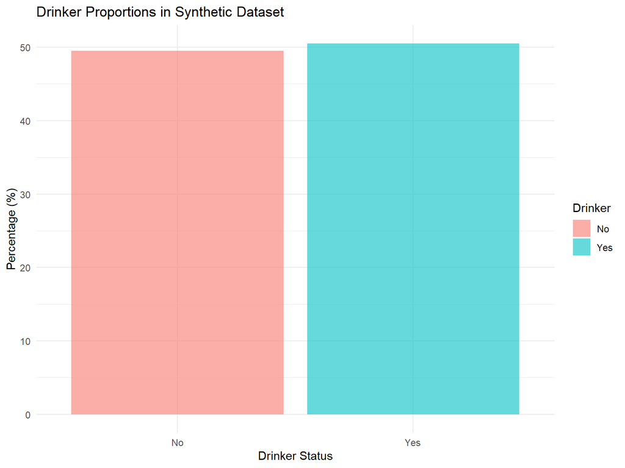

```r
# Convert drinker proportions to a data frame for plotting
drinker_df <- as.data.frame(prop.table(table(patients_full$drinker)) * 100)
colnames(drinker_df) <- c("Drinker", "Percentage")

# Create a bar plot of drinker proportions
ggplot(drinker_df, aes(x = Drinker, y = Percentage, fill = Drinker)) +
  geom_bar(stat = "identity", alpha = 0.6) +
  labs(title = "Drinker Proportions in Synthetic Dataset", x = "Drinker Status", y = "Percentage (%)") +
  theme_minimal()
```